# EvanWB_Homework3

Evan Woelk Balzer

28/01/2020

#Calling necessary packages

```r
library(tidyverse)
library(car)
library(gvlma)
```

#1

```r
#Reading in the KIllarney data
lakes <- read_csv("Killarney.csv", col_types = cols(Diversity = "d", Status = "f", Lake = "c"))
lakes
```

```
## # A tibble: 45 x 3
##    Lake            Status Diversity
##    <chr>           <fct>      <dbl>
##  1 Acid            Acidic      2
##  2 Clearsilver     Acidic      4.65
##  3 David           Acidic      4.09
##  4 deLamorandiere  Acidic      1.11
##  5 Freeland        Acidic      2.06
##  6 Gail            Acidic      1.02
##  7 Killarney       Acidic      2.57
##  8 Little Mountain Acidic      1.03
##  9 Little Superior Acidic      1
## 10 Lumsden         Acidic      1.75
## # … with 35 more rows
```

#2

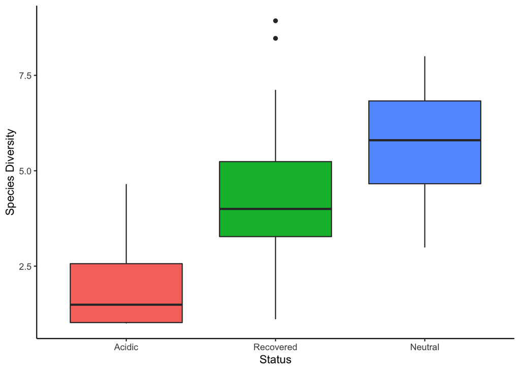

```r
#Generating a Status~Diversity boxplot
a <- ggplot(lakes, aes(x = Status, y = Diversity, fill = Status))
lakesboxplot <- a+geom_boxplot(show.legend = FALSE)+theme_classic()+ylab('Species Diversity')
lakesboxplot
```

There appears to be a difference betweeen acidic and neutral lakes, and likely also a difference between acidic and recovered lakes. There may be a difference between neutral and recovered lakes, but since the boxes overlap, further testing is necessary to determine whether there is in fact a significant difference between the two.

#3

```r
#Anova among lake types for species diversity
Diversity <- lakes$Diversity
Status <- lakes$Status
lakedivfit <- aov(Diversity~Status)
lakedivfit
```

```
## Call:
##    aov(formula = Diversity ~ Status)
##
## Terms:
##                    Status Residuals
## Sum of Squares   97.40958 124.68215
## Deg. of Freedom         2        42
##
## Residual standard error: 1.722969
## Estimated effects may be unbalanced
```

#4 H0: There is no difference in species diversity among each of the three lake types

#5

```r
summary(lakedivfit)
```

```
##             Df Sum Sq Mean Sq F value   Pr(>F)
## Status       2  97.41   48.70   16.41 5.43e-06 ***
## Residuals   42 124.68    2.97
## ---
## Signif. codes:  0 '***' 0.001 '**' 0.01 '*' 0.05 '.' 0.1 ' ' 1
```

p-value = 5.43e-06 Test statistic: F

#6 Since p < 0.05, we reject H0. Species diversity differs among the three lake types.

#7

```r
TukeyHSD(aov(Diversity~Status))
```

```
##   Tukey multiple comparisons of means
##     95% family-wise confidence level
##
## Fit: aov(formula = Diversity ~ Status)
##
## $Status
##                       diff       lwr      upr     p adj
## Recovered-Acidic  2.418485  1.016843 3.820127 0.0004023
## Neutral-Acidic    3.603068  1.874854 5.331282 0.0000253
## Neutral-Recovered 1.184583 -0.648012 3.017179 0.2695118
```

#8 As suspected, there are significant differences between Recovered-Acidic and Neutral-Acidic.

#9

```r
#Getting residuals#
ldfres <- lakedivfit$residuals
ldfres
```

```
##            1            2            3            4            5            6
## -0.068181818  2.581818182  2.021818182 -0.958181818 -0.008181818 -1.048181818
##            7            8            9           10           11           12
##  0.501818182 -1.038181818 -1.068181818 -0.318181818  2.331818182 -1.028181818
##           13           14           15           16           17           18
## -0.838181818 -0.048181818 -1.048181818 -1.058181818  0.481818182 -1.038181818
##           19           20           21           22           23           24
## -1.058181818  2.371818182  1.391818182 -1.058181818  0.063333333  1.313333333
##           25           26           27           28           29           30
## -0.986666667 -1.326666667  4.443333333 -1.696666667  2.633333333  0.193333333
##           31           32           33           34           35           36
## -0.486666667 -1.096666667 -0.456666667 -2.316666667 -3.376666667 -0.886666667
##           37           38           39           40           41           42
##  3.983333333 -1.701250000  1.548750000  1.028750000 -0.781250000  0.318750000
##           43           44           45
##  2.328750000 -0.061250000 -2.681250000
```

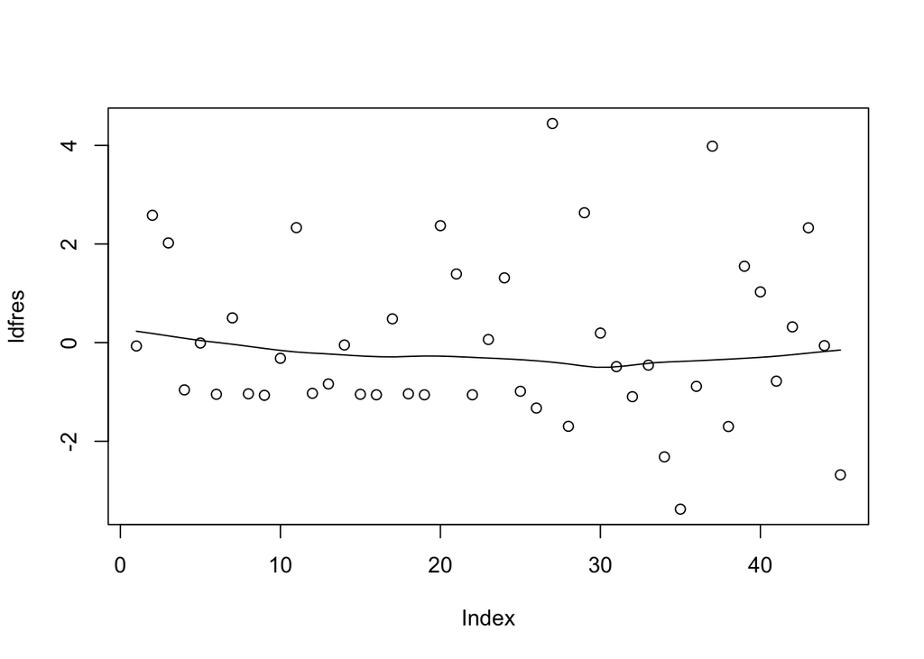

```r
#taking a look at the residuals#
scatter.smooth(ldfres)
```

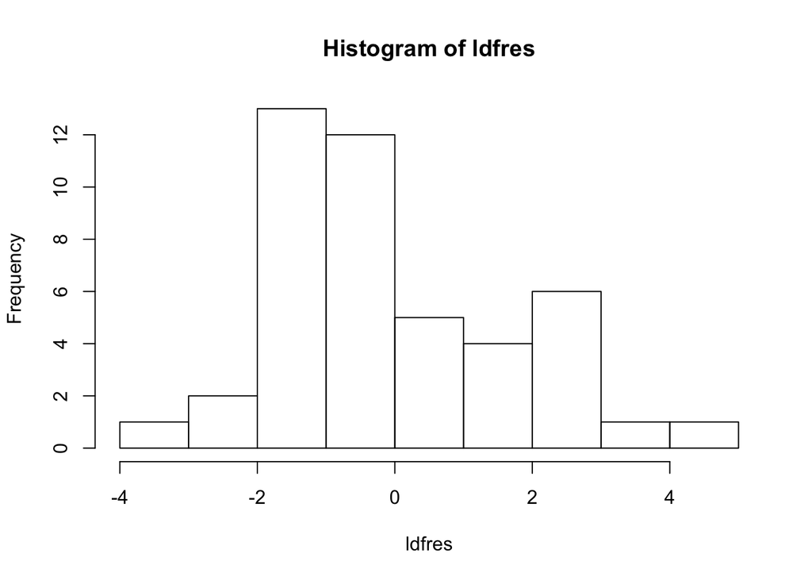

```r
hist(ldfres)
```

```r
#Testing for residual normality#
shapiro.test(ldfres)
```

```
##
##  Shapiro-Wilk normality test
##
## data:  ldfres
## W = 0.93501, p-value = 0.01415
```

Since p < 0.05, we reject the null hypothesis. The residuals are not normally distributed and these data not not meet the assumptions of ANOVA.

```r
leveneTest(Diversity, Status)
```

```
## Levene's Test for Homogeneity of Variance (center = median)
##       Df F value Pr(>F)
## group  2  0.9977 0.3773
##       42
```

Since p > 0.05, we fail to reject the null hypothsis. The data are homoscedastic.

#10 #a

```r
esoph <- read_csv("esoph.csv")
esoph
```

```
## # A tibble: 88 x 6
##       X1 Age   Alcohol   Tobacco  ncases ncontrols
##    <dbl> <chr> <chr>     <chr>     <dbl>     <dbl>
##  1     1 25-34 0-39g/day 0-9g/day      0        40
##  2     2 25-34 0-39g/day 10-19         0        10
##  3     3 25-34 0-39g/day 20-29         0         6
##  4     4 25-34 0-39g/day 30+           0         5
##  5     5 25-34 40-79     0-9g/day      0        27
##  6     6 25-34 40-79     10-19         0         7
##  7     7 25-34 40-79     20-29         0         4
##  8     8 25-34 40-79     30+           0         7
##  9     9 25-34 80-119    0-9g/day      0         2
## 10    10 25-34 80-119    10-19         0         1
## # … with 78 more rows
```

```r
ncases <- esoph$ncases
Alcohol <- esoph$Alcohol
Tobacco <- esoph$Tobacco

ATanova <- aov(ncases~Alcohol*Tobacco)
ATanova
```

```
## Call:
##    aov(formula = ncases ~ Alcohol * Tobacco)
##
## Terms:
##                  Alcohol  Tobacco Alcohol:Tobacco Residuals
## Sum of Squares   46.8707  41.5389         31.5116  539.5333
## Deg. of Freedom        3        3               9        72
##
## Residual standard error: 2.737429
## Estimated effects may be unbalanced
```

```r
summary(ATanova)
```

```
##                 Df Sum Sq Mean Sq F value Pr(>F)
## Alcohol          3   46.9  15.624   2.085  0.110
## Tobacco          3   41.5  13.846   1.848  0.146
## Alcohol:Tobacco  9   31.5   3.501   0.467  0.892
## Residuals       72  539.5   7.494
```

#11 #a

```r
Age <- esoph$Age

TAanova <- aov(ncases~Age*Tobacco)
TAanova
```

```
## Call:
##    aov(formula = ncases ~ Age * Tobacco)
##
## Terms:
##                       Age   Tobacco Age:Tobacco Residuals
## Sum of Squares  261.20152  52.96972    84.61664 260.66667
## Deg. of Freedom         5         3          15        64
##
## Residual standard error: 2.018147
## Estimated effects may be unbalanced
```

```r
summary(TAanova)
```

```
##             Df Sum Sq Mean Sq F value  Pr(>F)
## Age          5 261.20   52.24  12.826 1.2e-08 ***
## Tobacco      3  52.97   17.66   4.335 0.00763 **
## Age:Tobacco 15  84.62    5.64   1.385 0.18215
## Residuals   64 260.67    4.07
## ---
## Signif. codes:  0 '***' 0.001 '**' 0.01 '*' 0.05 '.' 0.1 ' ' 1
```

#b

```r
TukeyHSD(aov(TAanova))
```

```
##   Tukey multiple comparisons of means
##     95% family-wise confidence level
##
## Fit: aov(formula = TAanova)
##
## $Age
##                   diff        lwr        upr     p adj
## 35-44-25-34  0.5333333 -1.6316077  2.6982744 0.9783189
## 45-54-25-34  2.8083333  0.6774880  4.9391787 0.0033564
## 55-64-25-34  4.6833333  2.5524880  6.8141787 0.0000002
## 65-74-25-34  3.6000000  1.4350590  5.7649410 0.0001028
## 75+-25-34    1.1151515 -1.2383875  3.4686905 0.7316114
## 45-54-35-44  2.2750000  0.1441547  4.4058453 0.0296780
## 55-64-35-44  4.1500000  2.0191547  6.2808453 0.0000044
## 65-74-35-44  3.0666667  0.9017256  5.2316077 0.0013005
## 75+-35-44    0.5818182 -1.7717208  2.9353572 0.9779839
## 55-64-45-54  1.8750000 -0.2211951  3.9711951 0.1053407
## 65-74-45-54  0.7916667 -1.3391787  2.9225120 0.8830192
## 75+-45-54   -1.6931818 -4.0153959  0.6290322 0.2794932
## 65-74-55-64 -1.0833333 -3.2141787  1.0475120 0.6695191
## 75+-55-64   -3.5681818 -5.8903959 -1.2459678 0.0003880
## 75+-65-74   -2.4848485 -4.8383875 -0.1313095 0.0325950
##
## $Tobacco
##                       diff       lwr        upr     p adj
## 10-19-0-9g/day -0.83333333 -2.370109  0.7034420 0.4853668
## 20-29-0-9g/day -1.85739899 -3.469183 -0.2456155 0.0175826
## 30+-0-9g/day   -1.80648990 -3.418273 -0.1947064 0.0220542
## 20-29-10-19    -1.02406566 -2.635849  0.5877179 0.3446841
## 30+-10-19      -0.97315657 -2.584940  0.6386270 0.3900235
## 30+-20-29       0.05090909 -1.632544  1.7343621 0.9998160
##
## $`Age:Tobacco`
##                                        diff          lwr         upr     p adj
## 35-44:0-9g/day-25-34:0-9g/day  5.000000e-01  -4.92250361  5.92250361 1.0000000
## 45-54:0-9g/day-25-34:0-9g/day  3.500000e+00  -1.92250361  8.92250361 0.7044917
## 55-64:0-9g/day-25-34:0-9g/day  6.250000e+00   0.82749639 11.67250361 0.0086982
## 65-74:0-9g/day-25-34:0-9g/day  7.750000e+00   2.32749639 13.17250361 0.0002200
## 75+:0-9g/day-25-34:0-9g/day    1.500000e+00  -3.92250361  6.92250361 0.9999909
## 25-34:10-19-25-34:0-9g/day     2.500000e-01  -5.17250361  5.67250361 1.0000000
```

[output cut: 255 more lines]

```
## 35-44:30+-25-34:30+            1.017704e-16  -5.85697331  5.85697331 1.0000000
## 45-54:30+-25-34:30+            2.750000e+00  -2.67250361  8.17250361 0.9536697
## 55-64:30+-25-34:30+            4.000000e+00  -1.42250361  9.42250361 0.4540368
## 65-74:30+-25-34:30+            6.666667e-01  -5.19030664  6.52363997 1.0000000
## 75+:30+-25-34:30+              1.000000e+00  -5.64118349  7.64118349 1.0000000
## 45-54:30+-35-44:30+            2.750000e+00  -3.10697331  8.60697331 0.9791234
## 55-64:30+-35-44:30+            4.000000e+00  -1.85697331  9.85697331 0.6036644
## 65-74:30+-35-44:30+            6.666667e-01  -5.59470117  6.92803451 1.0000000
## 75+:30+-35-44:30+              1.000000e+00  -6.00042206  8.00042206 1.0000000
## 55-64:30+-45-54:30+            1.250000e+00  -4.17250361  6.67250361 0.9999997
## 65-74:30+-45-54:30+           -2.083333e+00  -7.94030664  3.77363997 0.9994407
## 75+:30+-45-54:30+             -1.750000e+00  -8.39118349  4.89118349 0.9999962
## 65-74:30+-55-64:30+           -3.333333e+00  -9.19030664  2.52363997 0.8730024
## 75+:30+-55-64:30+             -3.000000e+00  -9.64118349  3.64118349 0.9864955
## 75+:30+-65-74:30+              3.333333e-01  -6.66708873  7.33375539 1.0000000
```

#12 #a

```r
AAanova <- aov(ncases~Age*Alcohol)
AAanova
```

```
## Call:
##    aov(formula = ncases ~ Age * Alcohol)
##
## Terms:
##                       Age   Alcohol Age:Alcohol Residuals
## Sum of Squares  261.20152  52.69529   107.55774 238.00000
## Deg. of Freedom         5         3          15        64
##
## Residual standard error: 1.928406
## Estimated effects may be unbalanced
```

```r
summary(AAanova)
```

```
##             Df Sum Sq Mean Sq F value   Pr(>F)
## Age          5  261.2   52.24  14.048 2.89e-09 ***
## Alcohol      3   52.7   17.57   4.723  0.00486 **
## Age:Alcohol 15  107.6    7.17   1.928  0.03633 *
## Residuals   64  238.0    3.72
## ---
## Signif. codes:  0 '***' 0.001 '**' 0.01 '*' 0.05 '.' 0.1 ' ' 1
```

#b

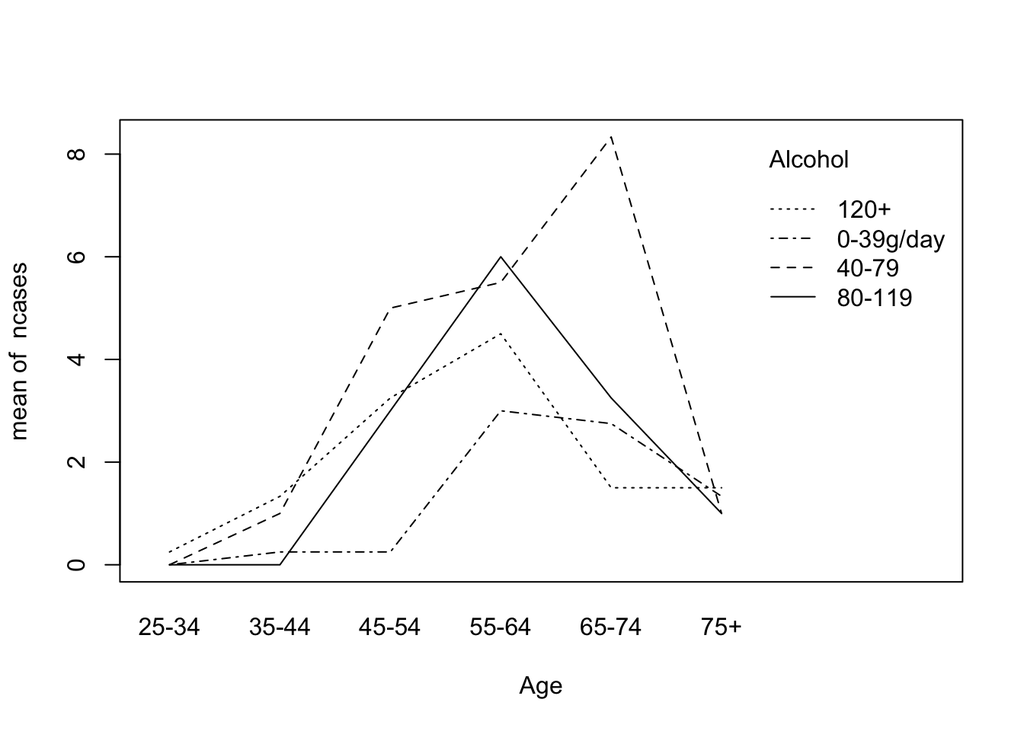

```r
interaction.plot(Age, Alcohol, ncases)
```

#c The interaction plot indicates that cases of esophageal cancer are most prevalent in individuals between the ages of 45-74 whose alcohol consumption is moderate. The significance of this interaction is supported by the ANOVA results which indicate a significant interaction between alcohol consumption and age. The frequency of esophageal cancer cannot be explained by either variable alone. Regardless of alcohol consumption, very old and very young individuals have a lower frequency of esophageal cancer than intermediate age classes.

#13

#a

```r
b <- ggplot(mtcars, aes(wt, mpg))
wtmpg_scatter <- b + geom_point()+theme_classic()+xlab('Vehicle Weight (tons)')+ylab('Fuel Efficiency (miles/gallon)')
```

#b

```r
wt <- mtcars$wt
mpg <- mtcars$mpg

wtmpg_glm <- glm(mpg~wt)
summary.lm(wtmpg_glm)
```

```
##
## Call:
## glm(formula = mpg ~ wt)
##
## Residuals:
##     Min      1Q  Median      3Q     Max
## -4.5432 -2.3647 -0.1252  1.4096  6.8727
##
## Coefficients:
##             Estimate Std. Error t value Pr(>|t|)
## (Intercept)  37.2851     1.8776  19.858  < 2e-16 ***
## wt           -5.3445     0.5591  -9.559 1.29e-10 ***
## ---
## Signif. codes:  0 '***' 0.001 '**' 0.01 '*' 0.05 '.' 0.1 ' ' 1
##
## Residual standard error: 3.046 on 30 degrees of freedom
## Multiple R-squared:  0.7528, Adjusted R-squared:  0.7446
## F-statistic: 91.38 on 1 and 30 DF,  p-value: 1.294e-10
```

```r
qt(0.05, 30)
```

```
## [1] -1.697261
```

Since |tobs| > |tcrit|, we reject H0. There is evidence for a significant relationship between weight and gas mileage. In other words, weight does have an influence on fuel efficiency.

#c

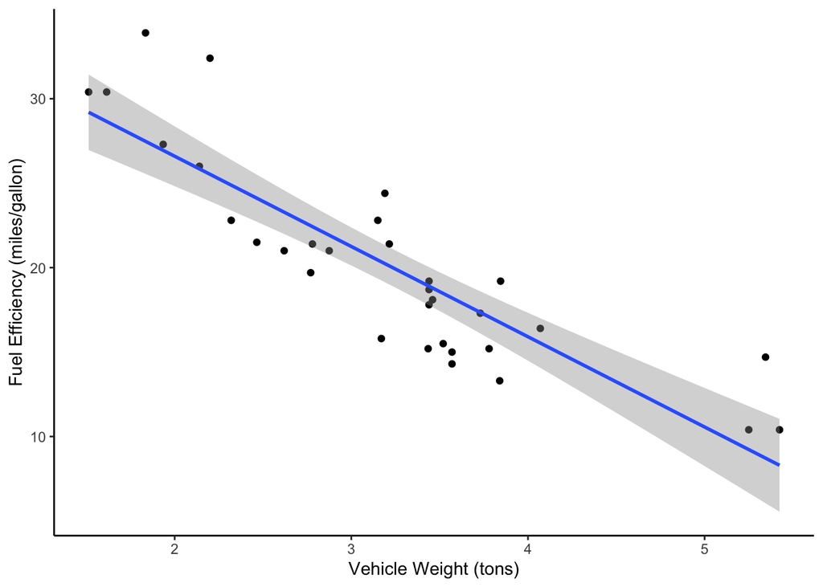

```r
#adding a fit line
bluefit <- wtmpg_scatter <- b + geom_point()+theme_classic()+xlab('Vehicle Weight (tons)')+ylab('Fuel Efficiency (miles/gallon)')+geom_smooth(method='lm')
bluefit
```

#d p-value: 1.29e-10 Since p<0.05, we reject H0. Gas mileage is significantly related to car weight.

#14 #a

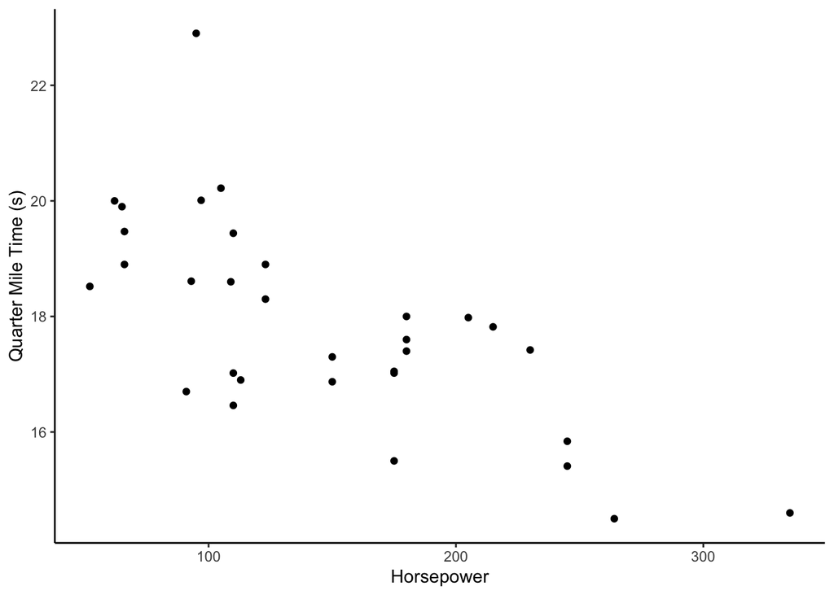

```r
#making objects for each column#
hp <- mtcars$hp
qsec <- mtcars$qsec
#creating the ggplot object and plotting the scatterplot#
c <- ggplot(mtcars, aes(hp, qsec))
qsechp_scatter <- c + geom_point()+theme_classic()+xlab('Horsepower')+ylab('Quarter Mile Time (s)')
qsechp_scatter
```

#b

```r
qsechp_glm <- glm(qsec~hp)
summary.lm(qsechp_glm)
```

```
##
## Call:
## glm(formula = qsec ~ hp)
##
## Residuals:
##     Min      1Q  Median      3Q     Max
## -2.1766 -0.6975  0.0348  0.6520  4.0972
##
## Coefficients:
##              Estimate Std. Error t value Pr(>|t|)
## (Intercept) 20.556354   0.542424  37.897  < 2e-16 ***
## hp          -0.018458   0.003359  -5.495 5.77e-06 ***
## ---
## Signif. codes:  0 '***' 0.001 '**' 0.01 '*' 0.05 '.' 0.1 ' ' 1
##
## Residual standard error: 1.282 on 30 degrees of freedom
## Multiple R-squared:  0.5016, Adjusted R-squared:  0.485
## F-statistic: 30.19 on 1 and 30 DF,  p-value: 5.766e-06
```

#c

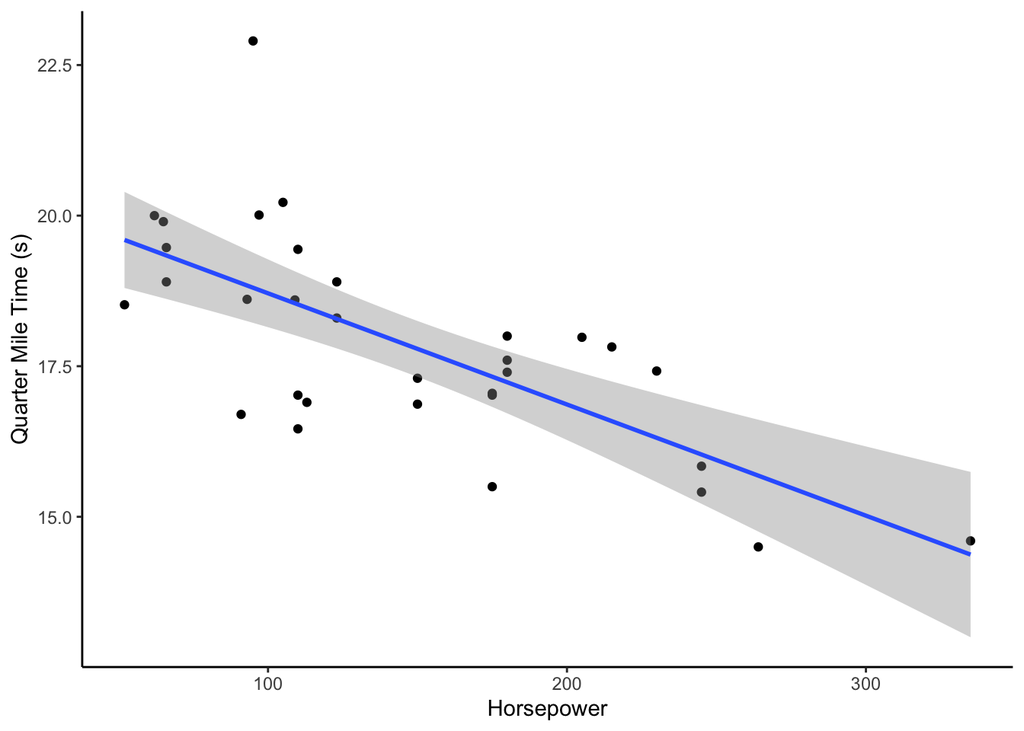

```r
qsechpline_scatter <- c + geom_point()+theme_classic()+xlab('Horsepower')+ylab('Quarter Mile Time (s)')+geom_smooth(method = lm)
qsechpline_scatter
```

Equation: Quater Mile Time = 20.556 - 0.0.18(Horsepower)

#d 20.566 - 0.018*300

#e p-value: 5.77e-06 Since p < 0.05, we reject H0. There is a significant relationship between horsepower and quarter mile time.

#f

```r
assumptions_qsechp <-gvlma(lm(qsechp_glm))
assumptions_qsechp
```

```
##
## Call:
## lm(formula = qsechp_glm)
##
## Coefficients:
## (Intercept)           hp
##    20.55635     -0.01846
##
##
## ASSESSMENT OF THE LINEAR MODEL ASSUMPTIONS
## USING THE GLOBAL TEST ON 4 DEGREES-OF-FREEDOM:
## Level of Significance =  0.05
##
## Call:
##  gvlma(x = lm(qsechp_glm))
##
##                       Value p-value                   Decision
## Global Stat        8.148631 0.08628    Assumptions acceptable.
## Skewness           2.876131 0.08990    Assumptions acceptable.
## Kurtosis           4.338691 0.03726 Assumptions NOT satisfied!
## Link Function      0.001639 0.96771    Assumptions acceptable.
## Heteroscedasticity 0.932170 0.33430    Assumptions acceptable.
```

This data meets all regression assumptions except Kurtosis.

#15 #a These data are the forearm length measurements of captured bats and the height(m) at which they were captured. If wing length is a predictor of flying strength, then I predict that individuals with larger wings will be caught a greater height.

```r
HF <- read_csv("HeightForearm.csv")
```

#15b

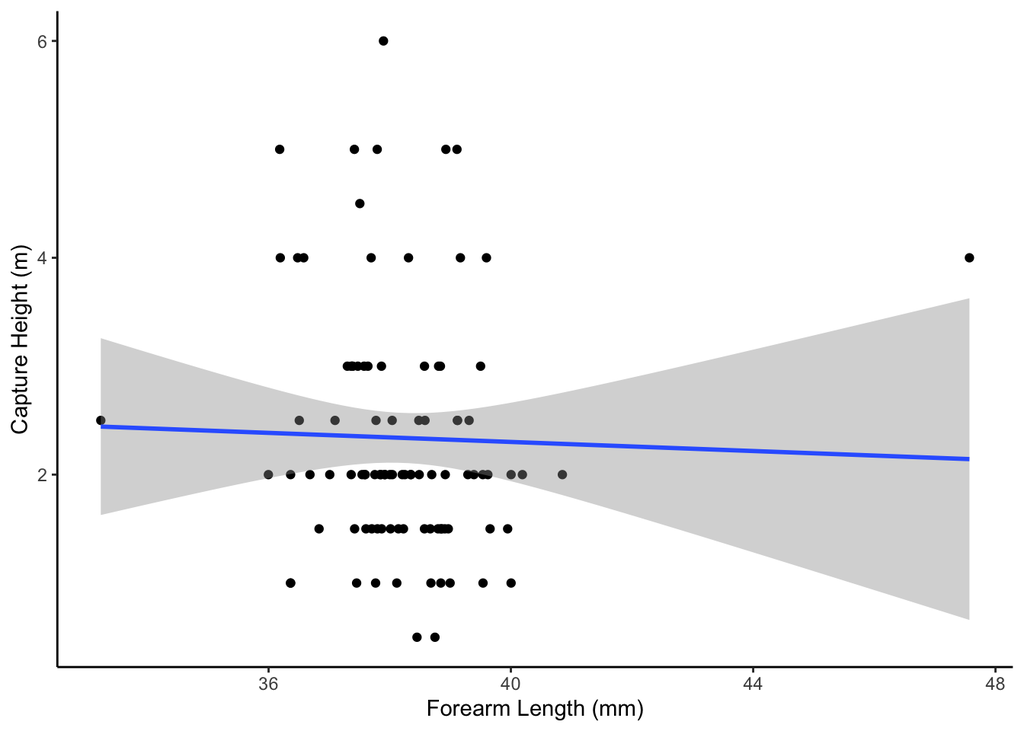

```r
d <- ggplot(HF, aes(Forearm, Height))
HF_scatter <- d + geom_point()+theme_classic()+xlab('Forearm Length (mm)')+ylab('Capture Height (m)')+geom_smooth(method = lm)
HF_scatter
```

#15c

```r
HF_glm <- glm(HF$Height~HF$Forearm)
summary.lm(HF_glm)
```

```
##
## Call:
## glm(formula = HF$Height ~ HF$Forearm)
##
## Residuals:
##     Min      1Q  Median      3Q     Max
## -1.8337 -0.8258 -0.3359  0.6439  3.6547
##
## Coefficients:
##             Estimate Std. Error t value Pr(>|t|)
## (Intercept)  3.13779    3.01973   1.039    0.301
## HF$Forearm  -0.02091    0.07895  -0.265    0.792
##
## Residual standard error: 1.138 on 94 degrees of freedom
## Multiple R-squared:  0.0007458,  Adjusted R-squared:  -0.009885
## F-statistic: 0.07016 on 1 and 94 DF,  p-value: 0.7917
```

```r
sqrt(0.0007458)
```

```
## [1] 0.02730934
```

#d p-value: 0.792 Since p >>> 0.05, we fail to reject the null hypothesis. There is no evidence for a relationship between forearm (wing) length and capture height.